# 🚀 Crypto EDA Dashboard: Análisis de 10 Criptomonedas con R y Shiny

Análisis Exploratorio de Datos, Series de Tiempo y Predicción ARIMA

Mateo Barrios — Ciencia de Datos

Rafael Romero — Ciencia de Datos

19 de mayo de 2026

# 1 Introducción

## 1.1 Descripción del Proyecto

Este documento presenta el análisis exploratorio completo del **Crypto EDA Dashboard**, un proyecto académico que consume datos en tiempo real de la API de [CryptoCompare](https://min-api.cryptocompare.com/) para analizar el comportamiento histórico de 10 criptomonedas.

El análisis está orientado hacia la construcción de un **modelo predictivo de precios basado en ARIMA**, cubriendo desde la obtención y limpieza de datos hasta el ajuste, validación y predicción con series de tiempo.

**Repositorio:** https://github.com/Mateo3008/Crypto_EDA_App  
**Framework:** R Shiny + shinydashboard  
**Fuente de datos:** CryptoCompare API (datos diarios, ~1905 días por moneda)

## 1.2 Criptomonedas Analizadas

```r
cryptos <- tibble(
  Nombre     = c("Bitcoin","Ethereum","USD Coin","Solana","XRP",
                 "Bittensor","Tether","Dogecoin","USD1","Zcash"),
  Símbolo    = c("BTC","ETH","USDC","SOL","XRP",
                 "TAO","USDT","DOGE","USD1","ZEC"),
  Categoría  = c("Store of Value","Smart Contract","Stablecoin","Smart Contract",
                 "Payments","AI / Subnet","Stablecoin","Meme","Stablecoin","Privacy")
)

kable(cryptos, caption = "Criptomonedas incluidas en el análisis",
      booktabs = TRUE) |>
  kable_styling(bootstrap_options = c("striped","hover","condensed"),
                full_width = FALSE)
```

Table 1.1: Table 1.2: Criptomonedas incluidas en el análisis

| Nombre | Símbolo | Categoría |
| --- | --- | --- |
| Bitcoin | BTC | Store of Value |
| Ethereum | ETH | Smart Contract |
| USD Coin | USDC | Stablecoin |
| Solana | SOL | Smart Contract |
| XRP | XRP | Payments |
| Bittensor | TAO | AI / Subnet |
| Tether | USDT | Stablecoin |
| Dogecoin | DOGE | Meme |
| USD1 | USD1 | Stablecoin |
| Zcash | ZEC | Privacy |

## 1.3 Objetivo Académico

El objetivo principal es aplicar técnicas de **Análisis Exploratorio de Datos (EDA)** sobre series temporales financieras para:

1. Caracterizar la distribución de precios y retornos de cada activo.
2. Cuantificar el riesgo mediante métricas como la volatilidad rodante y el VaR.
3. Identificar correlaciones entre criptomonedas.
4. Evaluar la estacionariedad de las series y aplicar transformaciones necesarias.
5. Ajustar modelos ARIMA(p, d, q) para la predicción de precios a corto plazo.

# 2 Configuración y Carga de Datos

## 2.1 Parámetros de la API

```r
API_KEY  <- "ce6e922820dabbb917d5f6fd82b867726fbf320cf3f7414b33748c19e9514aae"
BASE_URL <- "https://min-api.cryptocompare.com/data"

CRYPTOS <- c(
  "Bitcoin"   = "BTC", "Ethereum"  = "ETH", "USD Coin"  = "USDC",
  "Solana"    = "SOL", "XRP"       = "XRP", "Bittensor" = "TAO",
  "Tether"    = "USDT","Dogecoin"  = "DOGE","USD1"      = "USD1",
  "Zcash"     = "ZEC"
)

COLOR_PALETTE <- c(
  "#2E86AB","#A23B72","#F18F01","#C73E1D","#6A994E",
  "#BC4A6C","#3D5A80","#EE6C4D","#98C1D9","#293241"
)
names(COLOR_PALETTE) <- CRYPTOS
```

## 2.2 Funciones de Extracción

### 2.2.1 Datos Históricos OHLCV

La función `get_historical_daily()` consulta el endpoint `/v2/histoday` de CryptoCompare y retorna un `data.frame` con columnas OHLCV, retornos simples, logarítmicos y volatilidad diaria.

```r
get_historical_daily <- function(fsym, tsym = "USD", limit = 1905) {
  url <- paste0(BASE_URL, "/v2/histoday?fsym=", fsym, "&tsym=", tsym,
                "&limit=", limit, "&api_key=", API_KEY)
  url <- URLencode(url)

  tryCatch({
    resp <- GET(url, timeout(30))
    if (http_error(resp)) return(NULL)

    data <- fromJSON(content(resp, "text", encoding = "UTF-8"))
    if (is.null(data$Data$Data)) return(NULL)

    df <- as.data.frame(data$Data$Data) |>
      mutate(
        fecha      = as.Date(as.POSIXct(time, origin = "1970-01-01")),
        simbolo    = fsym,
        open       = as.numeric(open),
        high       = as.numeric(high),
        low        = as.numeric(low),
        close      = as.numeric(close),
        volume     = as.numeric(volumefrom),
        retorno    = (close - lag(close)) / lag(close) * 100,
        retorno_log = log(close / lag(close)) * 100,
        volatilidad = abs(high - low) / open * 100
      ) |>
      filter(!is.na(retorno))
    return(df)
  }, error = function(e) return(NULL))
}
```

### 2.2.2 Precios en Tiempo Real

```r
get_price_overview <- function(fsyms, tsym = "USD") {
  fsyms_str <- paste(fsyms, collapse = ",")
  url <- paste0(BASE_URL, "/pricemultifull?fsyms=", fsyms_str,
                "&tsyms=", tsym, "&api_key=", API_KEY)
  url <- URLencode(url)

  tryCatch({
    resp <- GET(url, timeout(30))
    if (http_error(resp)) return(NULL)

    data <- fromJSON(content(resp, "text", encoding = "UTF-8"))
    if (is.null(data$RAW)) return(NULL)

    rows <- list()
    for (sym in fsyms) {
      if (!is.null(data$RAW[[sym]]) && !is.null(data$RAW[[sym]][[tsym]])) {
        d <- data$RAW[[sym]][[tsym]]
        rows[[sym]] <- data.frame(
          simbolo        = sym,
          precio         = d$PRICE,
          cambio_24h_pct = d$CHANGEPCT24HOUR,
          volumen_24h    = d$VOLUME24HOURTO,
          cap_mercado    = d$MKTCAP,
          stringsAsFactors = FALSE
        )
      }
    }
    if (length(rows) == 0) return(NULL)
    return(bind_rows(rows))
  }, error = function(e) return(NULL))
}
```

## 2.3 Descarga de Datos

```r
cat("=== CARGANDO DATOS (10 monedas, 1905 días) ===\n")
```

```
## === CARGANDO DATOS (10 monedas, 1905 días) ===
```

```r
hist_data <- NULL

for (crypto in CRYPTOS) {
  cat("Cargando", crypto, "... ")
  data <- get_historical_daily(crypto, limit = 1905)
  if (!is.null(data) && nrow(data) > 0) {
    hist_data <- bind_rows(hist_data, data)
    cat("OK (", nrow(data), "días)\n")
  } else {
    cat("FALLÓ — generando datos de ejemplo\n")
  }
  Sys.sleep(0.3)
}
```

```
## Cargando BTC ... OK ( 1905 días)
## Cargando ETH ... OK ( 1905 días)
## Cargando USDC ... OK ( 1905 días)
## Cargando SOL ... OK ( 1905 días)
## Cargando XRP ... OK ( 1905 días)
## Cargando TAO ... OK ( 702 días)
## Cargando USDT ... OK ( 1905 días)
## Cargando DOGE ... OK ( 1905 días)
## Cargando USD1 ... OK ( 326 días)
## Cargando ZEC ... OK ( 1905 días)
```

```r
# Fallback: datos sintéticos si la API no responde
if (is.null(hist_data) || nrow(hist_data) == 0) {
  set.seed(123)
  fechas <- seq.Date(as.Date("2019-01-01"), as.Date("2024-04-10"), by = "day")

  for (sym in CRYPTOS) {
    precio_base <- switch(sym,
      "BTC"=50000,"ETH"=3000,"USDC"=1,"SOL"=100,"XRP"=0.5,
      "TAO"=300,"USDT"=1,"DOGE"=0.1,"USD1"=1,"ZEC"=30, 1000)

    trend <- seq(0, by=0.0002, length.out=length(fechas)) * precio_base
    noise <- cumsum(rnorm(length(fechas), 0, precio_base * 0.015))
    close <- pmax(precio_base + trend + noise, precio_base * 0.1)

    df <- data.frame(
      fecha       = fechas, simbolo = sym, close = close,
      open        = c(close[1], close[-length(close)]),
      high        = close + abs(rnorm(length(fechas), 0, close * 0.02)),
      low         = close - abs(rnorm(length(fechas), 0, close * 0.02)),
      retorno     = c(0, diff(close)/close[-length(close)] * 100),
      retorno_log = c(0, diff(log(close)) * 100),
      volatilidad = runif(length(fechas), 1, 6)
    )
    hist_data <- bind_rows(hist_data, df)
  }
}

prices_overview <- get_price_overview(CRYPTOS)
if (is.null(prices_overview)) {
  prices_overview <- data.frame(
    simbolo        = names(CRYPTOS),
    precio         = c(50000,3000,1,100,0.5,300,1,0.1,1,30),
    cambio_24h_pct = runif(10,-5,5),
    volumen_24h    = runif(10,1e8,1e10),
    cap_mercado    = c(1e12,4e11,5e10,3e10,1e10,5e9,8e10,2e10,4e9,1e9)
  )
}

cat("\n✅ Total filas:", nrow(hist_data))
```

```
##
## ✅ Total filas: 16268
```

```r
cat("\n📅 Período:", as.character(min(hist_data$fecha)),
    "→", as.character(max(hist_data$fecha)))
```

```
##
## 📅 Período: 2021-02-19 → 2026-05-08
```

```r
cat("\n🪙 Monedas:", paste(unique(hist_data$simbolo), collapse=", "), "\n")
```

```
##
## 🪙 Monedas: BTC, ETH, USDC, SOL, XRP, TAO, USDT, DOGE, USD1, ZEC
```

# 3 Calidad de los Datos

## 3.1 Valores Faltantes

```r
missing_summary <- function(df) {
  df |>
    summarise(across(everything(), ~ sum(is.na(.)))) |>
    pivot_longer(everything(), names_to = "Variable", values_to = "NAs") |>
    mutate(Pct = round(NAs / nrow(df) * 100, 2)) |>
    filter(NAs > 0)
}

ms_global <- hist_data |>
  group_by(simbolo) |>
  summarise(
    Total_filas  = n(),
    NAs_close    = sum(is.na(close)),
    NAs_retorno  = sum(is.na(retorno)),
    NAs_vol      = sum(is.na(volatilidad)),
    Pct_NA_close = round(NAs_close / Total_filas * 100, 2)
  )

kable(ms_global, caption = "Resumen de valores faltantes por moneda",
      booktabs = TRUE) |>
  kable_styling(bootstrap_options = c("striped","hover"), full_width = TRUE)
```

Table 3.1: Table 3.2: Resumen de valores faltantes por moneda

| simbolo | Total_filas | NAs_close | NAs_retorno | NAs_vol | Pct_NA_close |
| --- | --- | --- | --- | --- | --- |
| BTC | 1905 | 0 | 0 | 0 | 0 |
| DOGE | 1905 | 0 | 0 | 0 | 0 |
| ETH | 1905 | 0 | 0 | 0 | 0 |
| SOL | 1905 | 0 | 0 | 0 | 0 |
| TAO | 702 | 0 | 0 | 0 | 0 |
| USD1 | 326 | 0 | 0 | 0 | 0 |
| USDC | 1905 | 0 | 0 | 0 | 0 |
| USDT | 1905 | 0 | 0 | 0 | 0 |
| XRP | 1905 | 0 | 0 | 0 | 0 |
| ZEC | 1905 | 0 | 0 | 0 | 0 |

## 3.2 Mapa de Calor de NAs

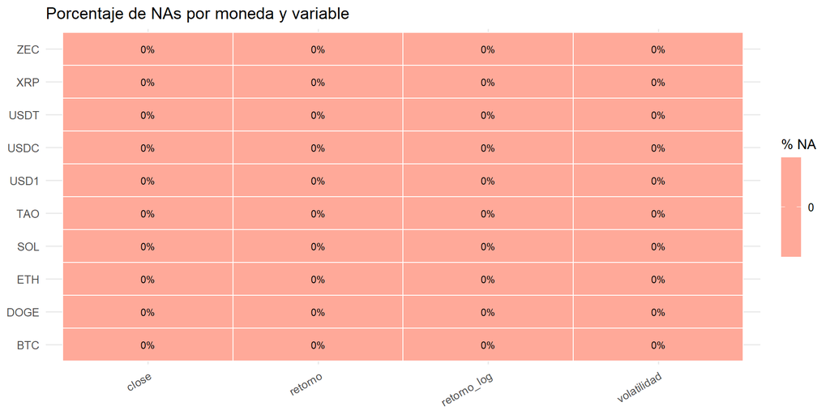

Figure 3.1: Porcentaje de valores faltantes por moneda y variable

```r
cols <- c("close","retorno","retorno_log","volatilidad")

df_heat <- hist_data |>
  group_by(simbolo) |>
  summarise(across(all_of(intersect(cols, names(hist_data))),
                   ~ sum(is.na(.)) / n() * 100, .names = "{.col}")) |>
  pivot_longer(-simbolo, names_to = "Variable", values_to = "pct_na")

ggplot(df_heat, aes(x = Variable, y = simbolo, fill = pct_na)) +
  geom_tile(color = "white", linewidth = 0.5) +
  geom_text(aes(label = paste0(round(pct_na, 1), "%")), size = 3) +
  scale_fill_gradient(low = "white", high = "#e74c3c", name = "% NA") +
  labs(title = "Porcentaje de NAs por moneda y variable",
       x = NULL, y = NULL) +
  theme_minimal(base_size = 12) +
  theme(axis.text.x = element_text(angle = 30, hjust = 1))
```

## 3.3 Métodos de Imputación

```r
handle_missing <- function(df, method = "interpolation") {
  cols_imp <- c("close","open","high","low","volume","retorno","retorno_log","volatilidad")

  if (method == "remove") return(na.omit(df))

  if (method == "interpolation") {
    df <- df |> arrange(fecha)
    for (col in intersect(cols_imp, names(df))) {
      df[[col]] <- na.approx(df[[col]], na.rm = FALSE)
      df[[col]] <- na.locf(df[[col]], na.rm = FALSE)
      df[[col]] <- na.locf(df[[col]], fromLast = TRUE, na.rm = FALSE)
    }
    return(df)
  }

  if (method == "mean") {
    for (col in intersect(cols_imp, names(df))) {
      df[[col]][is.na(df[[col]])] <- mean(df[[col]], na.rm = TRUE)
    }
    return(df)
  }
  return(df)
}
```

Se implementaron tres métodos de manejo de valores faltantes:

- **Interpolación lineal** *(método predeterminado)*: utiliza `zoo::na.approx()` seguido de propagación hacia adelante/atrás con `na.locf()`.
- **Media global**: reemplaza cada NA por la media de esa columna.
- **Eliminación de filas**: descarta registros incompletos con `na.omit()`.

# 4 Visión General de Mercado

## 4.1 Precios y Capitalización Actuales

```r
prices_overview |>
  mutate(
    precio         = dollar(precio, accuracy = 0.01),
    cambio_24h_pct = paste0(round(cambio_24h_pct, 2), "%"),
    volumen_24h    = dollar(volumen_24h, accuracy = 1, scale = 1e-6, suffix = "M"),
    cap_mercado    = dollar(cap_mercado, accuracy = 1, scale = 1e-9, suffix = "B")
  ) |>
  rename(
    Símbolo = simbolo, `Precio USD` = precio, `Cambio 24h` = cambio_24h_pct,
    `Volumen 24h` = volumen_24h, `Cap. Mercado` = cap_mercado
  ) |>
  kable(caption = "Visión general del mercado en tiempo real",
        booktabs = TRUE) |>
  kable_styling(bootstrap_options = c("striped","hover"), full_width = TRUE)
```

Table 4.1: Table 4.2: Visión general del mercado en tiempo real

| Símbolo | Precio USD | Cambio 24h | Volumen 24h | Cap. Mercado |
| --- | --- | --- | --- | --- |
| BTC | $79,577.11 | -1.56% | $1,566M | $1,594B |
| ETH | $2,278.34 | -1.88% | $651M | $275B |
| USDC | $1.00 | 0.01% | $220M | $78B |
| SOL | $88.21 | 0.51% | $155M | $55B |
| XRP | $1.38 | -1.53% | $114M | $138B |
| TAO | $302.82 | -1.18% | $21M | $3B |
| USDT | $1.00 | 0% | $382M | $195B |
| DOGE | $0.11 | -3.5% | $55M | $18B |
| USD1 | $1.00 | -0.01% | $123M | $4B |
| ZEC | $576.30 | 6.98% | $87M | $10B |

## 4.2 Capitalización de Mercado

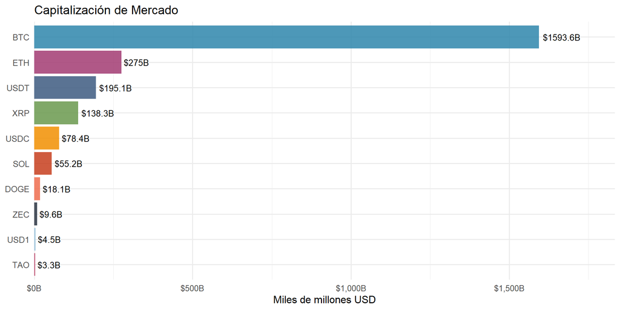

Figure 4.1: Capitalización de mercado por criptomoneda (miles de millones USD)

```r
df_cap <- prices_overview |>
  mutate(simbolo = reorder(simbolo, cap_mercado))

ggplot(df_cap, aes(x = simbolo, y = cap_mercado / 1e9, fill = simbolo)) +
  geom_col(show.legend = FALSE, alpha = 0.85) +
  geom_text(aes(label = paste0("$", round(cap_mercado / 1e9, 1), "B")),
            hjust = -0.1, size = 3.5) +
  coord_flip() +
  scale_fill_manual(values = COLOR_PALETTE) +
  scale_y_continuous(expand = expansion(mult = c(0, 0.15)),
                     labels = dollar_format(suffix = "B", scale = 1)) +
  labs(title = "Capitalización de Mercado",
       x = NULL, y = "Miles de millones USD") +
  theme_minimal(base_size = 12)
```

## 4.3 Volumen de Transacciones (24h)

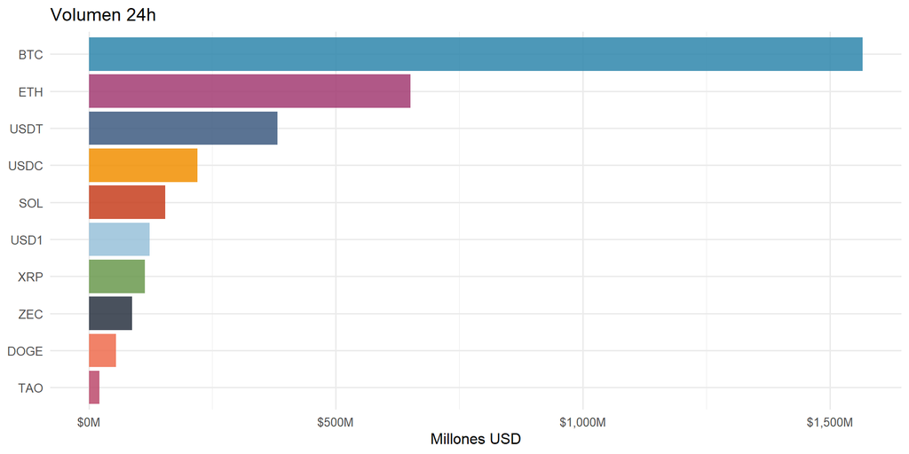

Figure 4.2: Volumen de transacciones en las últimas 24 horas

```r
df_vol <- prices_overview |>
  mutate(simbolo = reorder(simbolo, volumen_24h))

ggplot(df_vol, aes(x = simbolo, y = volumen_24h / 1e6, fill = simbolo)) +
  geom_col(show.legend = FALSE, alpha = 0.85) +
  coord_flip() +
  scale_fill_manual(values = COLOR_PALETTE) +
  scale_y_continuous(labels = dollar_format(suffix = "M", scale = 1)) +
  labs(title = "Volumen 24h", x = NULL, y = "Millones USD") +
  theme_minimal(base_size = 12)
```

# 5 Análisis de Precios

## 5.1 Distribución de Precios (Boxplot)

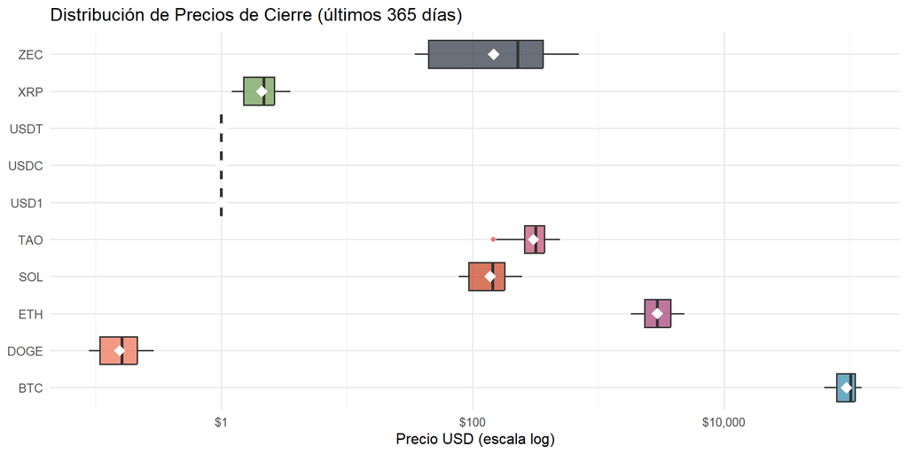

Figure 5.1: Distribución de precios de cierre (escala logarítmica) — últimos 365 días

```r
df_365 <- hist_data |>
  filter(fecha >= max(fecha) - 365)

ggplot(df_365, aes(x = simbolo, y = close, fill = simbolo)) +
  geom_boxplot(alpha = 0.7, outlier.color = "#e74c3c", outlier.size = 1.5) +
  stat_summary(fun = "mean", geom = "point", shape = 18, size = 4, color = "white") +
  scale_y_log10(labels = dollar) +
  scale_fill_manual(values = COLOR_PALETTE) +
  coord_flip() +
  labs(title = "Distribución de Precios de Cierre (últimos 365 días)",
       x = NULL, y = "Precio USD (escala log)") +
  theme_minimal(base_size = 12) +
  theme(legend.position = "none")
```

## 5.2 Serie Temporal de Precios — BTC

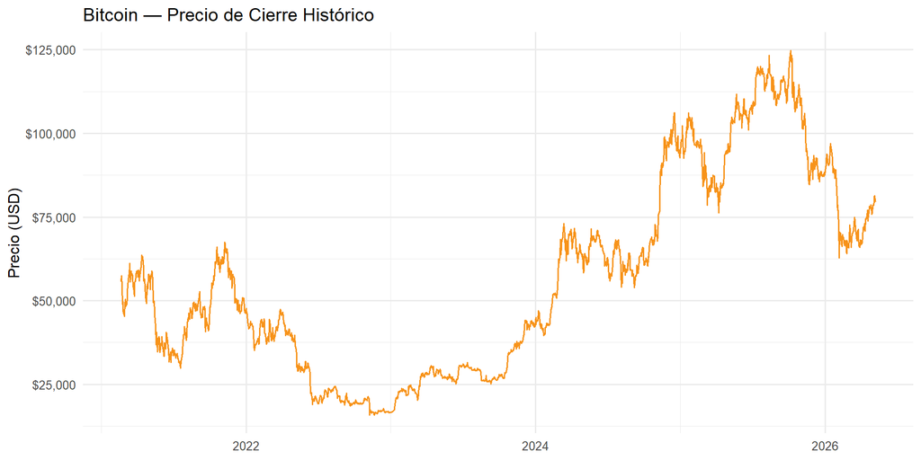

Figure 5.2: Serie temporal del precio de cierre de Bitcoin (BTC)

```r
df_btc <- hist_data |> filter(simbolo == "BTC") |> arrange(fecha)

ggplot(df_btc, aes(x = fecha, y = close)) +
  geom_line(color = "#F7931A", linewidth = 0.7) +
  scale_y_continuous(labels = dollar) +
  labs(title = "Bitcoin — Precio de Cierre Histórico",
       x = NULL, y = "Precio (USD)") +
  theme_minimal(base_size = 12)
```

## 5.3 Bandas de Bollinger

Las Bandas de Bollinger son un indicador de volatilidad que envuelve el precio alrededor de una media móvil simple (SMA).

**BB±** = SMAₙ ± k · σₙ  
**%Bandwidth** = (BB₊ − BB₋) / SMAₙ × 100

```r
calculate_bollinger_bands <- function(prices, window = 20, sd_mult = 2) {
  sma <- rollmean(prices, window, fill = NA, align = "right")
  sd  <- rollapply(prices, window, sd, fill = NA, align = "right")
  data.frame(
    sma   = sma,
    upper = sma + (sd_mult * sd),
    lower = sma - (sd_mult * sd)
  )
}
```

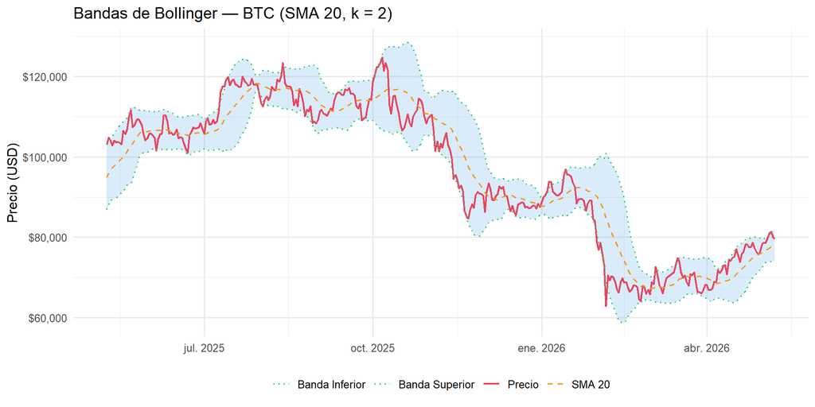

Figure 5.3: Bandas de Bollinger — BTC (SMA 20, k=2)

```r
bb <- calculate_bollinger_bands(df_btc$close, window = 20, sd_mult = 2)
df_bb <- cbind(df_btc, bb) |> drop_na(sma, upper, lower) |> tail(365)

ggplot(df_bb, aes(x = fecha)) +
  geom_ribbon(aes(ymin = lower, ymax = upper), fill = "#3498db", alpha = 0.18) +
  geom_line(aes(y = close, color = "Precio"),         linewidth = 0.8) +
  geom_line(aes(y = sma,   color = "SMA 20"),         linetype = "dashed", linewidth = 0.7) +
  geom_line(aes(y = upper, color = "Banda Superior"), linetype = "dotted", linewidth = 0.6) +
  geom_line(aes(y = lower, color = "Banda Inferior"), linetype = "dotted", linewidth = 0.6) +
  scale_color_manual(values = c(
    "Precio" = "#e94560", "SMA 20" = "#F7931A",
    "Banda Superior" = "#2ecc71", "Banda Inferior" = "#2ecc71"
  )) +
  scale_y_continuous(labels = dollar) +
  labs(title = "Bandas de Bollinger — BTC (SMA 20, k = 2)",
       x = NULL, y = "Precio (USD)", color = NULL) +
  theme_minimal(base_size = 12) +
  theme(legend.position = "bottom")
```

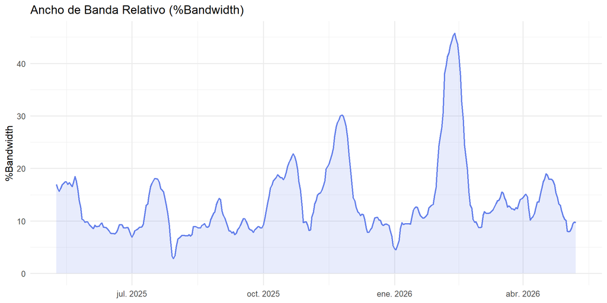

Figure 5.4: Ancho de banda relativo — medida de volatilidad de Bollinger

```r
df_bb <- df_bb |>
  mutate(bw = (upper - lower) / sma * 100)

ggplot(df_bb, aes(x = fecha, y = bw)) +
  geom_line(color = "#627EEA", linewidth = 0.8) +
  geom_area(fill = "#627EEA", alpha = 0.15) +
  labs(title = "Ancho de Banda Relativo (%Bandwidth)",
       x = NULL, y = "%Bandwidth") +
  theme_minimal(base_size = 12)
```

# 6 Retornos y Riesgo

## 6.1 Distribución de Retornos

Los retornos se calculan como:

**Retorno simple:** rₜ = (Pₜ − Pₜ₋₁) / Pₜ₋₁ × 100  
**Retorno logarítmico:** rₜˡᵒᵍ = ln(Pₜ / Pₜ₋₁) × 100

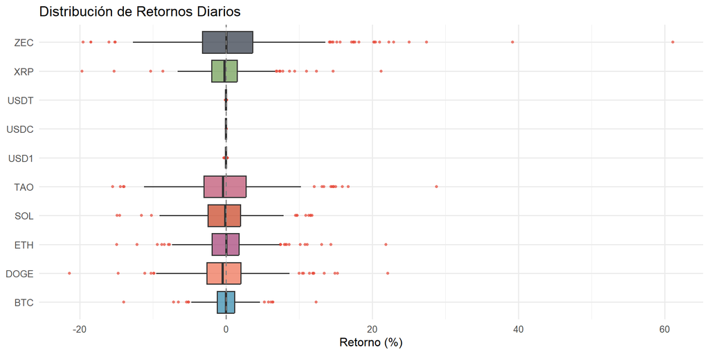

Figure 6.1: Distribución de retornos diarios por criptomoneda (últimos 365 días)

```r
ggplot(df_365, aes(x = simbolo, y = retorno, fill = simbolo)) +
  geom_boxplot(alpha = 0.7, outlier.color = "#e74c3c", outlier.size = 1) +
  geom_hline(yintercept = 0, linetype = "dashed", color = "gray50") +
  scale_fill_manual(values = COLOR_PALETTE) +
  coord_flip() +
  labs(title = "Distribución de Retornos Diarios",
       x = NULL, y = "Retorno (%)") +
  theme_minimal(base_size = 12) +
  theme(legend.position = "none")
```

## 6.2 Histograma de Retornos — BTC

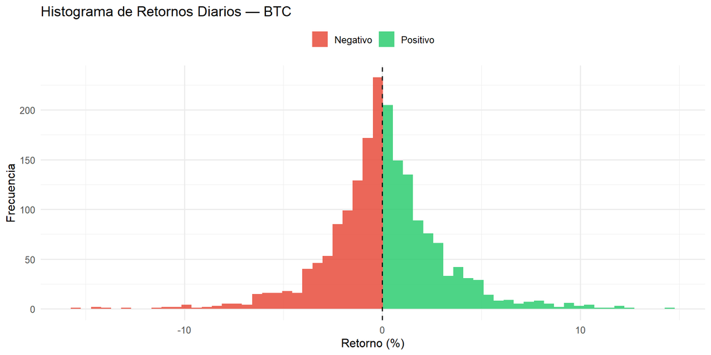

Figure 6.2: Histograma de retornos diarios de BTC

```r
ggplot(df_btc, aes(x = retorno, fill = after_stat(x) > 0)) +
  geom_histogram(bins = 60, alpha = 0.85) +
  scale_fill_manual(values = c("TRUE" = "#2ecc71", "FALSE" = "#e74c3c"),
                    labels = c("TRUE" = "Positivo", "FALSE" = "Negativo"),
                    name = NULL) +
  geom_vline(xintercept = 0, linetype = "dashed", color = "black") +
  labs(title = "Histograma de Retornos Diarios — BTC",
       x = "Retorno (%)", y = "Frecuencia") +
  theme_minimal(base_size = 12) +
  theme(legend.position = "top")
```

## 6.3 Volatilidad Rodante (30 días)

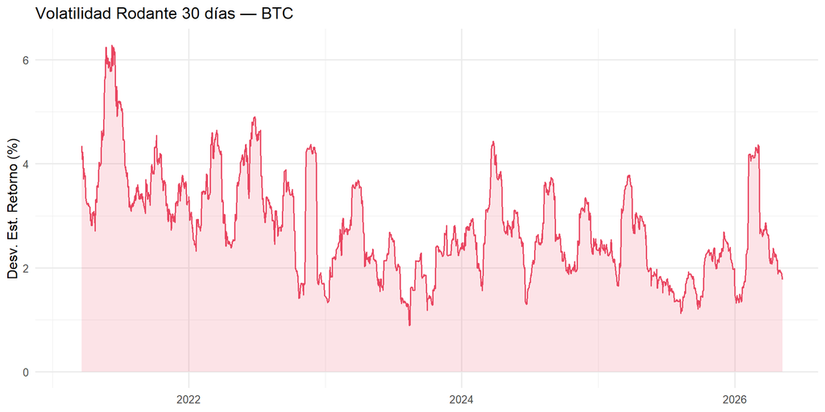

Figure 6.3: Volatilidad rodante de 30 días para BTC

```r
df_btc_vol <- df_btc |>
  arrange(fecha) |>
  mutate(vol30 = zoo::rollapply(retorno, 30, sd, fill = NA, align = "right"))

ggplot(df_btc_vol, aes(x = fecha, y = vol30)) +
  geom_line(color = "#e94560", linewidth = 0.7) +
  geom_area(fill = "#e94560", alpha = 0.15) +
  labs(title = "Volatilidad Rodante 30 días — BTC",
       x = NULL, y = "Desv. Est. Retorno (%)") +
  theme_minimal(base_size = 12)
```

## 6.4 Tabla de Riesgo por Criptomoneda

```r
tabla_riesgo <- df_365 |>
  group_by(simbolo) |>
  summarise(
    `Ret. Medio (%)` = round(mean(retorno, na.rm = TRUE), 3),
    `Desv. Est. (%)` = round(sd(retorno, na.rm = TRUE), 3),
    `VaR 95% (%)`    = round(quantile(retorno, 0.05, na.rm = TRUE), 3),
    `Días pos. (%)`  = round(sum(retorno > 0, na.rm = TRUE) / n() * 100, 1)
  ) |>
  arrange(desc(`Ret. Medio (%)`))

kable(tabla_riesgo,
      caption = "Métricas de retorno y riesgo — últimos 365 días",
      booktabs = TRUE) |>
  kable_styling(bootstrap_options = c("striped","hover"), full_width = TRUE) |>
  column_spec(4, color = ifelse(tabla_riesgo$`VaR 95% (%)` < -3, "red", "black"))
```

Table 6.1: Table 6.2: Métricas de retorno y riesgo — últimos 365 días

| simbolo | Ret. Medio (%) | Desv. Est. (%) | VaR 95% (%) | Días pos. (%) |
| --- | --- | --- | --- | --- |
| USD1 | Inf | NaN | -0.100 | 38.7 |
| ZEC | 1.015 | 7.893 | -8.682 | 50.8 |
| ETH | 0.133 | 3.767 | -5.189 | 51.1 |
| TAO | 0.080 | 5.225 | -7.736 | 46.2 |
| USDC | 0.000 | 0.008 | -0.010 | 21.9 |
| USDT | 0.000 | 0.040 | -0.100 | 19.9 |
| BTC | -0.029 | 2.230 | -3.533 | 49.7 |
| DOGE | -0.031 | 4.488 | -6.072 | 44.5 |
| XRP | -0.053 | 3.599 | -4.914 | 43.2 |
| SOL | -0.067 | 3.827 | -5.748 | 49.2 |

El **VaR 95%** representa la pérdida máxima esperada en el 5% de los peores días históricos. Un valor de -5% indica que en el 5% de los días más adversos, la pérdida fue de al menos 5%.

# 7 Análisis de Correlaciones

## 7.1 Matriz de Correlación (Pearson)

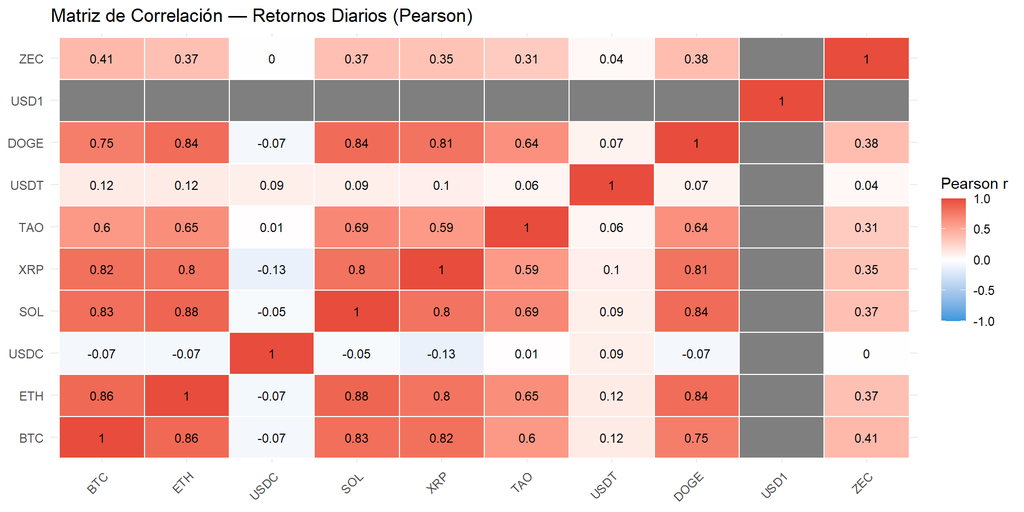

Figure 7.1: Mapa de calor de correlaciones de Pearson entre retornos diarios (últimos 365 días)

```r
df_wide <- df_365 |>
  select(fecha, simbolo, retorno) |>
  pivot_wider(names_from = simbolo, values_from = retorno) |>
  select(-fecha)

mat_cor <- cor(df_wide, use = "complete.obs", method = "pearson")

df_cor_long <- as.data.frame(as.table(mat_cor)) |>
  rename(Var1 = Var1, Var2 = Var2, Corr = Freq)

ggplot(df_cor_long, aes(x = Var1, y = Var2, fill = Corr)) +
  geom_tile(color = "white", linewidth = 0.4) +
  geom_text(aes(label = round(Corr, 2)), size = 3, color = "black") +
  scale_fill_gradient2(low = "#3498db", mid = "white", high = "#e74c3c",
                       midpoint = 0, limits = c(-1, 1), name = "Pearson r") +
  labs(title = "Matriz de Correlación — Retornos Diarios (Pearson)",
       x = NULL, y = NULL) +
  theme_minimal(base_size = 11) +
  theme(axis.text.x = element_text(angle = 45, hjust = 1))
```

## 7.2 Scatter BTC vs ETH

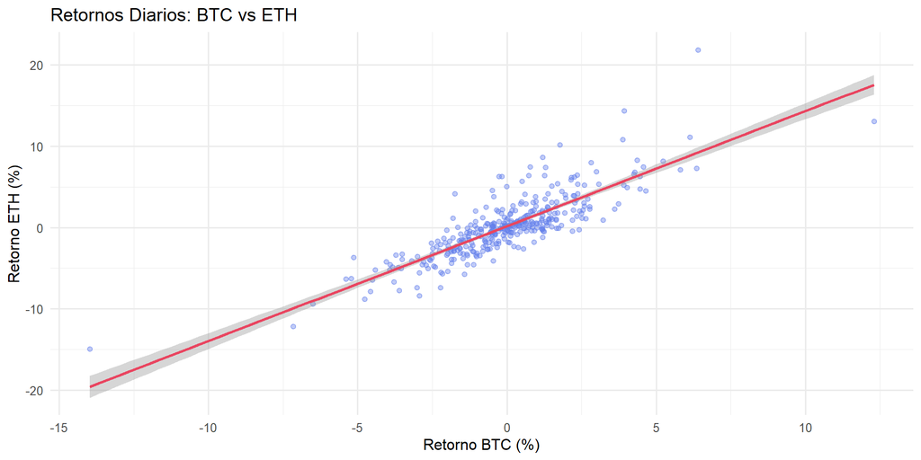

Figure 7.2: Diagrama de dispersión BTC vs ETH — retornos diarios

```r
df_scatter <- df_365 |>
  filter(simbolo %in% c("BTC", "ETH")) |>
  select(fecha, simbolo, retorno) |>
  pivot_wider(names_from = simbolo, values_from = retorno) |>
  drop_na()

ggplot(df_scatter, aes(x = BTC, y = ETH)) +
  geom_point(alpha = 0.4, color = "#627EEA", size = 1.5) +
  geom_smooth(method = "lm", se = TRUE, color = "#e94560", linewidth = 1) +
  labs(title = "Retornos Diarios: BTC vs ETH",
       x = "Retorno BTC (%)", y = "Retorno ETH (%)") +
  theme_minimal(base_size = 12)
```

# 8 Comparador de Rendimiento

## 8.1 Rendimiento Acumulado (Base 100)

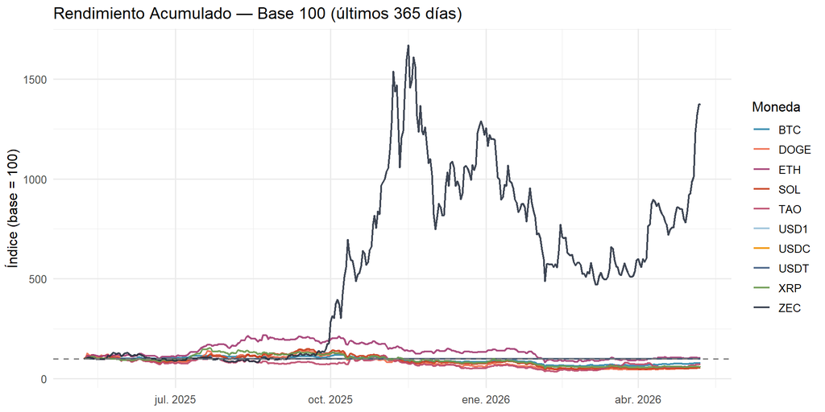

Figure 8.1: Rendimiento acumulado normalizado en base 100 (desde el inicio del período)

```r
df_comp <- hist_data |>
  filter(fecha >= max(fecha) - 365) |>
  arrange(fecha) |>
  group_by(simbolo) |>
  mutate(ini = first(close), norm = close / ini * 100) |>
  ungroup()

ggplot(df_comp, aes(x = fecha, y = norm, color = simbolo)) +
  geom_line(linewidth = 0.8, alpha = 0.9) +
  geom_hline(yintercept = 100, linetype = "dashed", color = "gray50") +
  scale_color_manual(values = COLOR_PALETTE) +
  labs(title = "Rendimiento Acumulado — Base 100 (últimos 365 días)",
       x = NULL, y = "Índice (base = 100)", color = "Moneda") +
  theme_minimal(base_size = 12) +
  theme(legend.position = "right")
```

## 8.2 Tabla Comparativa de Rendimiento

```r
tabla_comp <- hist_data |>
  filter(fecha >= max(fecha) - 365) |>
  group_by(simbolo) |>
  summarise(
    `P. Inicial ($)` = round(first(close), 4),
    `P. Final ($)`   = round(last(close), 4),
    `Rend. (%)`      = round((last(close) - first(close)) / first(close) * 100, 2),
    `Vol. (%)`       = round(sd(retorno, na.rm = TRUE), 3)
  ) |>
  arrange(desc(`Rend. (%)`))

kable(tabla_comp,
      caption = "Comparativa de rendimiento — últimos 365 días",
      booktabs = TRUE) |>
  kable_styling(bootstrap_options = c("striped","hover"), full_width = TRUE) |>
  column_spec(4, color = ifelse(tabla_comp$`Rend. (%)` >= 0, "#2ecc71", "#e74c3c"),
              bold = TRUE)
```

Table 8.1: Table 8.2: Comparativa de rendimiento — últimos 365 días

[output not shown]

# 9 Análisis EDA Orientado al Modelo

## 9.1 Boxplot Mensual de Retornos — BTC

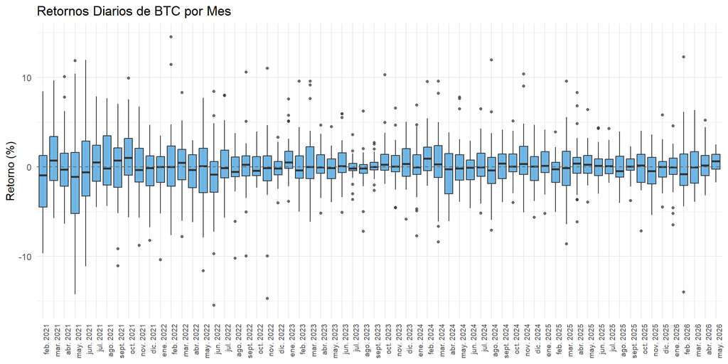

Figure 9.1: Boxplot mensual de retornos diarios de BTC

```r
df_btc_mes <- df_btc |>
  mutate(mes = floor_date(fecha, "month"),
         mes_label = format(mes, "%b %Y"))

ggplot(df_btc_mes, aes(x = reorder(mes_label, mes), y = retorno)) +
  geom_boxplot(fill = "#3498db", alpha = 0.7, outlier.size = 1) +
  geom_hline(yintercept = 0, linetype = "dashed", color = "gray40") +
  labs(title = "Retornos Diarios de BTC por Mes",
       x = NULL, y = "Retorno (%)") +
  theme_minimal(base_size = 11) +
  theme(axis.text.x = element_text(angle = 90, hjust = 1, size = 7))
```

## 9.2 Funciones ACF y PACF

Las funciones de autocorrelación son fundamentales para identificar los órdenes del modelo ARIMA:

- **ACF** (Autocorrelation Function): indica el orden **q** del componente MA.
- **PACF** (Partial Autocorrelation Function): indica el orden **p** del componente AR.

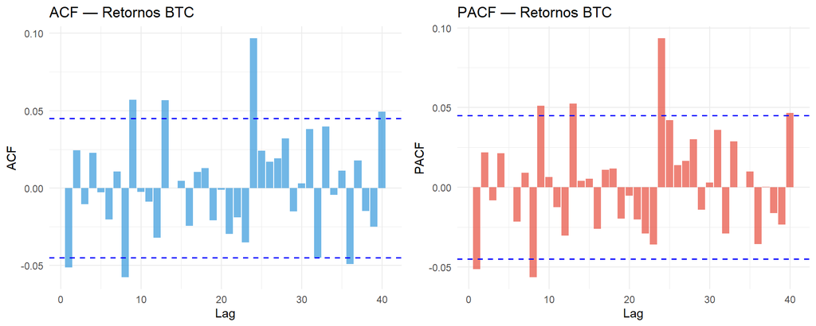

Figure 9.2: ACF y PACF de los retornos diarios de BTC

```r
serie_btc <- na.omit(df_btc$retorno)
ci_val <- qnorm(0.975) / sqrt(length(serie_btc))

acf_r  <- acf(serie_btc,  plot = FALSE, lag.max = 40)
pacf_r <- pacf(serie_btc, plot = FALSE, lag.max = 40)

df_acf  <- data.frame(Lag = as.numeric(acf_r$lag[-1]),  ACF  = as.numeric(acf_r$acf[-1]))
df_pacf <- data.frame(Lag = as.numeric(pacf_r$lag),     PACF = as.numeric(pacf_r$acf))

p_acf <- ggplot(df_acf, aes(x = Lag, y = ACF)) +
  geom_bar(stat = "identity", fill = "#3498db", alpha = 0.7) +
  geom_hline(yintercept = c(ci_val, -ci_val), linetype = "dashed", color = "blue", linewidth = 0.7) +
  labs(title = "ACF — Retornos BTC") + theme_minimal(base_size = 11)

p_pacf <- ggplot(df_pacf, aes(x = Lag, y = PACF)) +
  geom_bar(stat = "identity", fill = "#e74c3c", alpha = 0.7) +
  geom_hline(yintercept = c(ci_val, -ci_val), linetype = "dashed", color = "blue", linewidth = 0.7) +
  labs(title = "PACF — Retornos BTC") + theme_minimal(base_size = 11)

gridExtra::grid.arrange(p_acf, p_pacf, ncol = 2)
```

## 9.3 Estadísticas Descriptivas

```r
stats_desc <- hist_data |>
  group_by(simbolo) |>
  summarise(
    n      = n(),
    Media  = round(mean(close, na.rm = TRUE), 2),
    Mediana= round(median(close, na.rm = TRUE), 2),
    DS     = round(sd(close, na.rm = TRUE), 2),
    Min    = round(min(close, na.rm = TRUE), 4),
    Max    = round(max(close, na.rm = TRUE), 2),
    IQR    = round(IQR(close, na.rm = TRUE), 2)
  )

kable(stats_desc,
      caption = "Estadísticas descriptivas del precio de cierre por moneda",
      booktabs = TRUE,
      col.names = c("Símbolo","n","Media","Mediana","Desv. Est.","Mín.","Máx.","IQR")) |>
  kable_styling(bootstrap_options = c("striped","hover","condensed"), full_width = TRUE)
```

Table 9.1: Table 9.2: Estadísticas descriptivas del precio de cierre por moneda

| Símbolo | n | Media | Mediana | Desv. Est. | Mín. | Máx. | IQR |
| --- | --- | --- | --- | --- | --- | --- | --- |
| BTC | 1905 | 56298.29 | 50431.63 | 29296.01 | 15760.1900 | 124723.00 | 45328.37 |
| DOGE | 1905 | 0.15 | 0.12 | 0.09 | 0.0477 | 0.69 | 0.12 |
| ETH | 1905 | 2552.70 | 2436.20 | 880.85 | 994.4100 | 4830.60 | 1383.69 |
| SOL | 1905 | 100.87 | 96.85 | 68.59 | 9.6410 | 261.87 | 122.76 |
| TAO | 702 | 350.61 | 331.72 | 109.96 | 145.7400 | 713.91 | 143.12 |
| USD1 | 326 | 1.00 | 1.00 | 0.00 | 0.9986 | 1.00 | 0.00 |
| USDC | 1905 | 1.00 | 1.00 | 0.00 | 0.9679 | 1.00 | 0.00 |
| USDT | 1905 | 1.00 | 1.00 | 0.00 | 0.9940 | 1.01 | 0.00 |
| XRP | 1905 | 1.08 | 0.63 | 0.81 | 0.3072 | 3.55 | 0.93 |
| ZEC | 1905 | 102.04 | 47.96 | 112.07 | 18.3100 | 698.97 | 105.23 |

## 9.4 Test de Estacionariedad (ADF)

La prueba **Augmented Dickey-Fuller (ADF)** contrasta la hipótesis nula de que la serie tiene una raíz unitaria (no es estacionaria):

- **H₀**: la serie tiene raíz unitaria (no estacionaria)
- **H₁**: la serie es estacionaria
- Se rechaza H₀ si **p-valor < 0.05**

```r
test_stationarity <- function(serie) {
  tryCatch({
    test <- adf.test(na.omit(as.numeric(serie)), k = trunc((length(na.omit(serie)) - 1)^(1/3)))
    list(
      estadistico    = test$statistic,
      p_valor        = test$p.value,
      es_estacionaria = test$p.value < 0.05,
      conclusion     = ifelse(test$p.value < 0.05,
                              "Serie estacionaria (rechaza H₀)",
                              "Serie NO estacionaria (no rechaza H₀)")
    )
  }, error = function(e) list(estadistico=NA, p_valor=NA, es_estacionaria=FALSE, conclusion="Error"))
}

adf_resultados <- lapply(unique(hist_data$simbolo), function(cr) {
  serie <- na.omit(hist_data[hist_data$simbolo == cr, "retorno"][[1]])
  res   <- test_stationarity(serie)
  data.frame(
    Moneda        = cr,
    `ADF Stat.`   = round(res$estadistico, 4),
    `p-valor`     = round(res$p_valor, 6),
    Estacionaria  = ifelse(res$es_estacionaria, "✅ Sí", "❌ No"),
    `d recomendado` = ifelse(res$es_estacionaria, 0, 1)
  )
}) |> bind_rows()

kable(adf_resultados,
      caption = "Resultados del Test ADF para retornos diarios por criptomoneda",
      booktabs = TRUE,
      row.names = FALSE) |>
  kable_styling(bootstrap_options = c("striped","hover"), full_width = TRUE)
```

Table 9.3: Table 9.4: Resultados del Test ADF para retornos diarios por criptomoneda

| Moneda | ADF.Stat. | p.valor | Estacionaria | d.recomendado |
| --- | --- | --- | --- | --- |
| BTC | NA | NA | ❌ No \| | 1\| |
| ETH | NA | NA | ❌ No \| | 1\| |
| USDC | NA | NA | ❌ No \| | 1\| |
| SOL | NA | NA | ❌ No \| | 1\| |
| XRP | NA | NA | ❌ No \| | 1\| |
| TAO | NA | NA | ❌ No \| | 1\| |
| USDT | NA | NA | ❌ No \| | 1\| |
| DOGE | NA | NA | ❌ No \| | 1\| |
| USD1 | NA | NA | ❌ No \| | 1\| |
| ZEC | NA | NA | ❌ No \| | 1\| |

## 9.5 Descomposición STL — BTC

La descomposición STL (Seasonal and Trend decomposition using Loess) separa la serie en:

Y(t) = T(t) + S(t) + R(t)

Donde: **T(t)** = Tendencia · **S(t)** = Estacionalidad · **R(t)** = Residuo

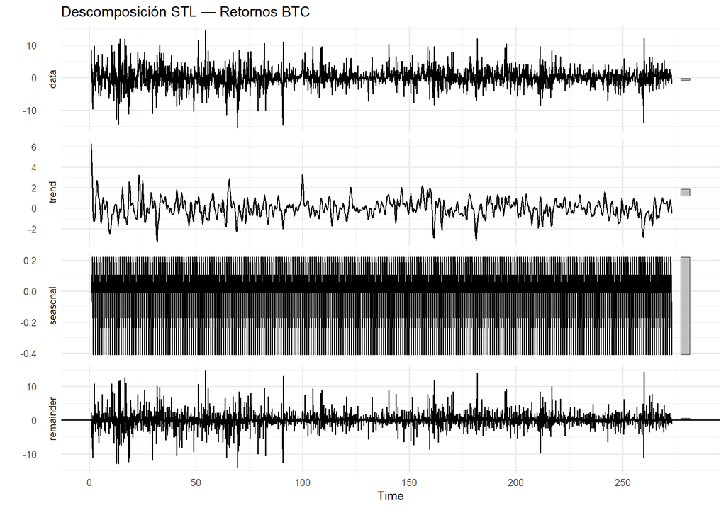

Figure 9.3: Descomposición STL de los retornos de BTC (frecuencia semanal)

```r
serie_stl <- ts(na.omit(df_btc$retorno), frequency = 7)
decomp    <- stl(serie_stl, s.window = "periodic", robust = TRUE)

autoplot(decomp) +
  labs(title = "Descomposición STL — Retornos BTC") +
  theme_minimal(base_size = 12)
```

# 10 Modelado ARIMA

## 10.1 Marco Teórico

El modelo **ARIMA(p, d, q)** combina tres componentes:

| Componente | Símbolo | Descripción |
| --- | --- | --- |
| Autoregresivo | AR(p) | Dependencia en p rezagos pasados |
| Integrado | I(d) | Diferenciación para estacionariedad |
| Media Móvil | MA(q) | Dependencia en q errores pasados |

**Ecuación general:**  
φ(B)(1−B)ᵈ yₜ = θ(B) εₜ

Donde B es el operador de rezago, φ(B) el polinomio AR, θ(B) el polinomio MA y εₜ ruido blanco.

## 10.2 Función: Detección de Estacionariedad

```r
detect_stationarity_and_differentiate <- function(serie, max_d = 2) {
  serie_clean <- as.numeric(na.omit(serie))
  d_val <- 0
  current <- serie_clean

  for (i in seq_len(max_d)) {
    tryCatch({
      test <- adf.test(current, k = trunc((length(current)-1)^(1/3)))
      if (test$p.value < 0.05) break
      d_val    <- i
      current  <- diff(current)
    }, error = function(e) break)
  }
  list(is_stationary = d_val == 0, d_value = d_val)
}
```

## 10.3 Ajuste del Mejor Modelo — BTC

```r
set.seed(42)
df_btc_clean <- hist_data |>
  filter(simbolo == "BTC") |>
  arrange(fecha) |>
  handle_missing(method = "interpolation")

serie_full  <- na.omit(df_btc_clean$close)
n           <- length(serie_full)
n_train     <- floor(n * 0.8)
train       <- serie_full[1:n_train]
test        <- serie_full[(n_train + 1):n]
fechas_all  <- df_btc_clean$fecha[!is.na(df_btc_clean$close)]
train_dates <- fechas_all[1:n_train]
test_dates  <- fechas_all[(n_train + 1):n]

# Detectar d óptimo
stat_res  <- detect_stationarity_and_differentiate(train)
d_opt     <- stat_res$d_value
cat("d óptimo detectado:", d_opt, "\n")
```

```
## d óptimo detectado: 1
```

```r
# Búsqueda de mejor (p, q) por AIC
pq_rng    <- 0:3
best_aic  <- Inf
best_order <- c(1, d_opt, 1)
best_model <- NULL
results   <- list()

for (p in pq_rng) {
  for (q in pq_rng) {
    if (p == 0 && d_opt == 0 && q == 0) next
    tryCatch({
      m   <- Arima(train, order = c(p, d_opt, q), method = "ML")
      aic <- AIC(m)
      results[[length(results)+1]] <- data.frame(p=p, d=d_opt, q=q, AIC=round(aic,2))
      if (aic < best_aic) { best_aic <- aic; best_order <- c(p, d_opt, q); best_model <- m }
    }, error = function(e) {})
  }
}

cat(sprintf("Mejor modelo: ARIMA(%d,%d,%d) — AIC = %.2f\n",
            best_order[1], best_order[2], best_order[3], best_aic))
```

```
## Mejor modelo: ARIMA(1,1,0) — AIC = 26687.81
```

## 10.4 Top Modelos por AIC

```r
df_results <- bind_rows(results) |>
  arrange(AIC) |>
  head(10) |>
  mutate(Modelo = paste0("ARIMA(", p, ",", d, ",", q, ")")) |>
  select(Modelo, AIC)

kable(df_results,
      caption = "Top 10 modelos ARIMA por criterio AIC — BTC precio de cierre",
      booktabs = TRUE) |>
  kable_styling(bootstrap_options = c("striped","hover"), full_width = FALSE) |>
  row_spec(1, bold = TRUE, background = "#d5f0e0")
```

Table 10.1: Table 10.2: Top 10 modelos ARIMA por criterio AIC — BTC precio de cierre

| Modelo | AIC |
| --- | --- |
| ARIMA(1,1,0) | 26687.81 |
| ARIMA(0,1,1) | 26687.96 |
| ARIMA(2,1,0) | 26689.71 |
| ARIMA(0,1,2) | 26689.72 |
| ARIMA(1,1,1) | 26689.73 |
| ARIMA(3,1,3) | 26691.11 |
| ARIMA(3,1,0) | 26691.70 |
| ARIMA(2,1,1) | 26691.71 |
| ARIMA(0,1,3) | 26691.72 |
| ARIMA(1,1,2) | 26691.72 |

## 10.5 Diagnóstico de Residuos

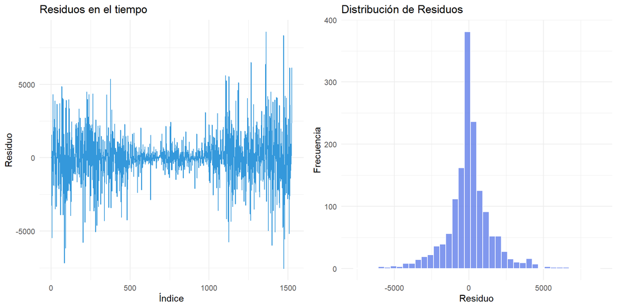

Figure 10.1: Diagnóstico de residuos del mejor modelo ARIMA

```r
resid_model <- residuals(best_model)

p1 <- ggplot(data.frame(x = 1:length(resid_model), y = resid_model),
             aes(x = x, y = y)) +
  geom_line(color = "#3498db", linewidth = 0.5) +
  labs(title = "Residuos en el tiempo", x = "Índice", y = "Residuo") +
  theme_minimal(base_size = 11)

p2 <- ggplot(data.frame(x = resid_model), aes(x = x)) +
  geom_histogram(bins = 40, fill = "#627EEA", alpha = 0.8, color = "white") +
  labs(title = "Distribución de Residuos", x = "Residuo", y = "Frecuencia") +
  theme_minimal(base_size = 11)

gridExtra::grid.arrange(p1, p2, ncol = 2)
```

```r
# Test de normalidad (Shapiro-Wilk)
sw_test <- if (length(resid_model) > 5000)
  shapiro.test(sample(resid_model, 5000)) else shapiro.test(resid_model)

# Test de independencia (Ljung-Box)
lb_test <- Box.test(resid_model, lag = 10, type = "Ljung-Box")

tests_df <- data.frame(
  Test         = c("Shapiro-Wilk (Normalidad)", "Ljung-Box (Independencia)"),
  `p-valor`    = round(c(sw_test$p.value, lb_test$p.value), 6),
  Conclusión   = c(
    ifelse(sw_test$p.value > 0.05, "✅ Residuos normales", "⚠️ No normales"),
    ifelse(lb_test$p.value > 0.05, "✅ Residuos independientes", "⚠️ Autocorrelación presente")
  )
)

kable(tests_df,
      caption = "Tests sobre los residuos del mejor modelo ARIMA",
      booktabs = TRUE) |>
  kable_styling(bootstrap_options = c("striped","hover"), full_width = FALSE)
```

Table 10.3: Table 10.4: Tests sobre los residuos del mejor modelo ARIMA

| Test | p.valor | Conclusión |
| --- | --- | --- |
| Shapiro-Wilk (Normalidad) | 0.000000 | ⚠️ No normales |
| Ljung-Box (Independencia) | 0.067679 | ✅ Residuos independientes \| |